# Lab 4

Author

Shubhu Shahade

Published

September 13, 2023

Remember, you must submit *both* your .Rmd and the compiled .html in order to receive full credit! In addition, to receive full credit, your code output and plots must be correctly formatted.

### Collaborators

```r
# LOAD ANY RELEVANT PACKAGES HERE
library(ggplot2)
library(dplyr)
```

## A. Penguins visualizations

1. For this lab, we’ll be using the `palmerpenguins` data. Use the following code to load the data.

```r
library(palmerpenguins)
data(penguins)
palmerpenguins::penguins
```

```
# A tibble: 344 × 8
   species island    bill_length_mm bill_depth_mm flipper_length_mm body_mass_g
   <fct>   <fct>              <dbl>         <dbl>             <int>       <int>
 1 Adelie  Torgersen           39.1          18.7               181        3750
 2 Adelie  Torgersen           39.5          17.4               186        3800
 3 Adelie  Torgersen           40.3          18                 195        3250
 4 Adelie  Torgersen           NA            NA                  NA          NA
 5 Adelie  Torgersen           36.7          19.3               193        3450
 6 Adelie  Torgersen           39.3          20.6               190        3650
 7 Adelie  Torgersen           38.9          17.8               181        3625
 8 Adelie  Torgersen           39.2          19.6               195        4675
 9 Adelie  Torgersen           34.1          18.1               193        3475
10 Adelie  Torgersen           42            20.2               190        4250
# ℹ 334 more rows
# ℹ 2 more variables: sex <fct>, year <int>
```

2. Create and interpret a histogram of `bill_length_mm` using base R code. Be sure to use meaningful axis labels and titles.

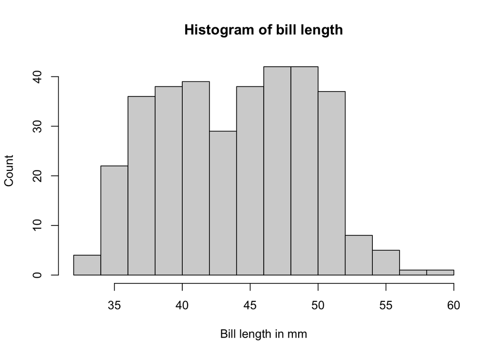

```r
# YOUR CODE HERE
hist(penguins$bill_length_mm,
     main = "Histogram of bill length",
     xlab = "Bill length in mm",
     ylab = "Count",
     axes = TRUE
)
```

Bill length varies but mostly between the values of 36- 52 mm. Maximum count is for values between 46-50 mm.

3. Create and interpret a histogram of `bill_length_mm` using ggplot2. Be sure to use meaningful axis labels and titles.

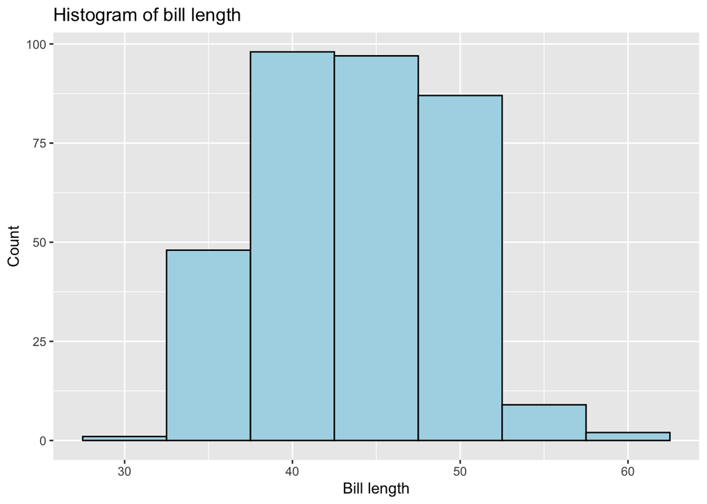

```r
# YOUR CODE HERE
ggplot(data = penguins, aes(x = penguins$bill_length_mm)) +
  geom_histogram(binwidth = 5, fill = "lightblue", color = "black") +
  labs(
    title = "Histogram of bill length",
    x = "Bill length",
    y = "Count"
  )
```

Bill length varies but mostly between the values of 36- 52 mm. Maximum count is for values between 38-52 mm.

4. Create and interpret a scatterplot of `bill_length_mm` versus `bill_depth_mm` using base R code. Be sure to use meaningful axis labels and titles.

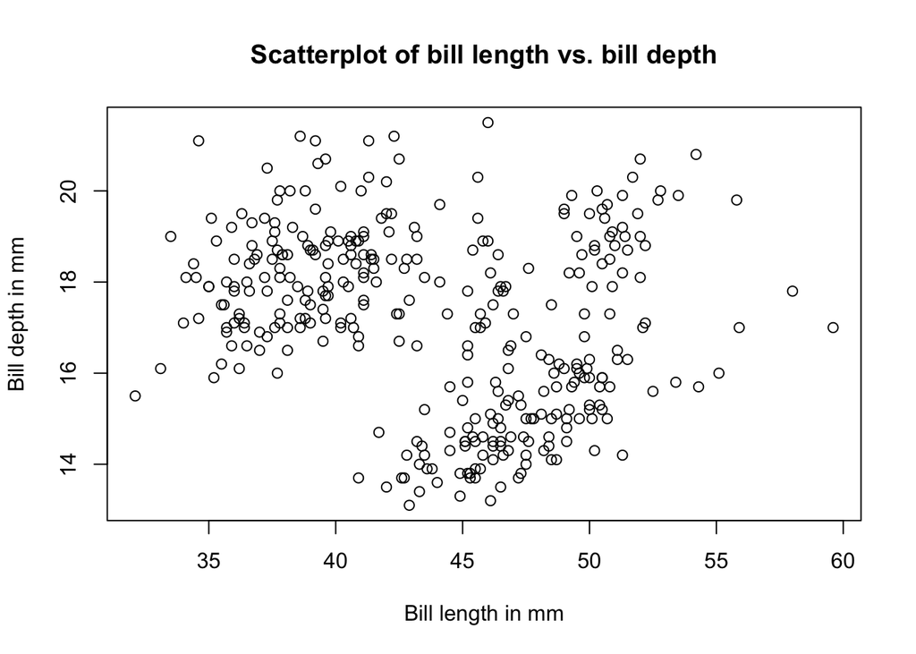

```r
# YOUR CODE HERE
plot(penguins$bill_length_mm, penguins$bill_depth_mm,
     main = "Scatterplot of bill length vs. bill depth",
     xlab = "Bill length in mm",
     ylab = "Bill depth in mm",
)
```

Most penguins with shorter bill length have longer bill depth and vice versa. Some have long length and depth.

5. Create and interpret a scatterplot of `bill_length_mm` versus `bill_depth_mm` using ggplot2. Be sure to use meaningful axis labels and titles.

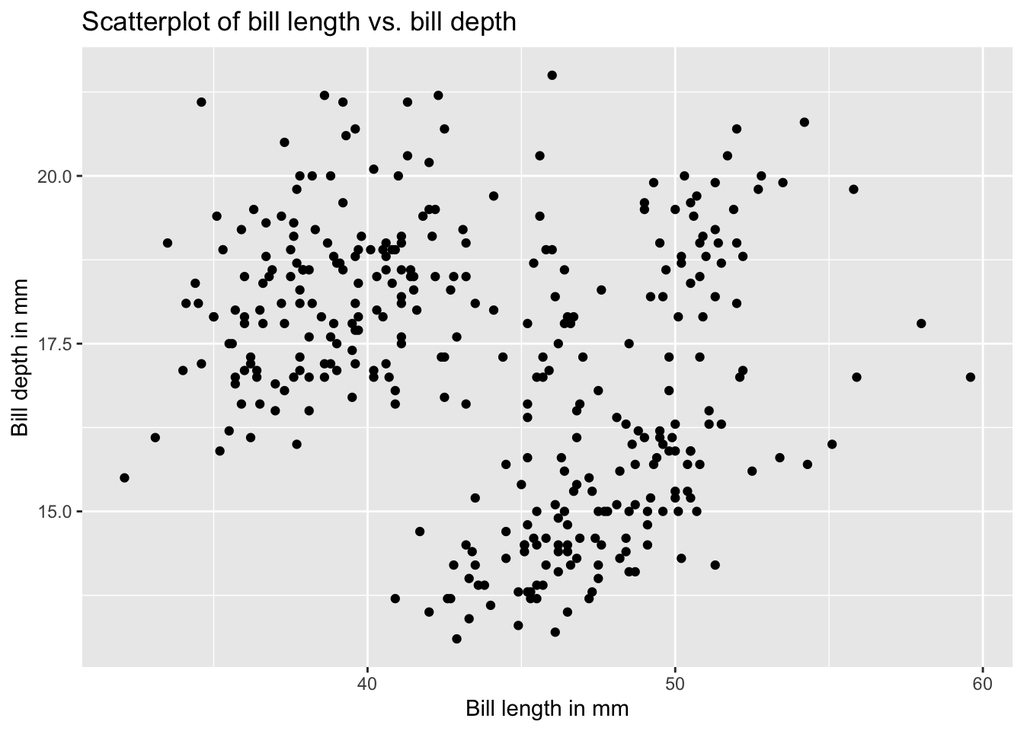

```r
# YOUR CODE HERE
ggplot(data = penguins, aes(x = penguins$bill_length_mm, y = penguins$bill_depth_mm)) +
  geom_point() +
  labs(
    title = "Scatterplot of bill length vs. bill depth",
    x = "Bill length in mm",
    y = "Bill depth in mm"
  )
```

Most penguins with shorter bill length have longer bill depth and vice versa. Some have long length and depth.

6. Update your `ggplot2` scatterplot of `bill_length_mm` versus `bill_depth_mm` using ggplot2 so that the color of a point represents the corresponding penguin’s species. What do you notice?

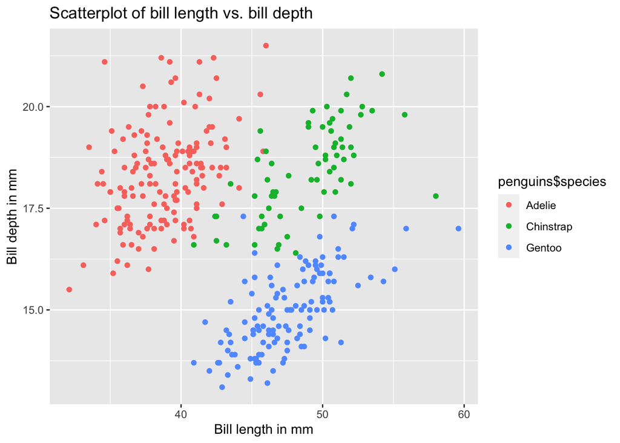

```r
# YOUR CODE HERE
ggplot(data = penguins, aes(x = penguins$bill_length_mm, y = penguins$bill_depth_mm, color = penguins$species)) +
  geom_point() +
  labs(
    title = "Scatterplot of bill length vs. bill depth",
    x = "Bill length in mm",
    y = "Bill depth in mm"
  )
```

## B. Your choice of data

7. Find and download a dataset from the Tidy Tuesday project (https://github.com/rfordatascience/tidytuesday).

```r
# YOUR CODE HERE
worldcups <- readr::read_csv('https://raw.githubusercontent.com/rfordatascience/tidytuesday/master/data/2022/2022-11-29/worldcups.csv')
worldcups
```

```
# A tibble: 21 × 10
    year host     winner second third fourth goals_scored teams games attendance
   <dbl> <chr>    <chr>  <chr>  <chr> <chr>         <dbl> <dbl> <dbl>      <dbl>
 1  1930 Uruguay  Urugu… Argen… USA   Yugos…           70    13    18     434000
 2  1934 Italy    Italy  Czech… Germ… Austr…           70    16    17     395000
 3  1938 France   Italy  Hunga… Braz… Sweden           84    15    18     483000
 4  1950 Brazil   Urugu… Brazil Swed… Spain            88    13    22    1337000
 5  1954 Switzer… West … Hunga… Aust… Urugu…          140    16    26     943000
 6  1958 Sweden   Brazil Sweden Fran… West …          126    16    35     868000
 7  1962 Chile    Brazil Czech… Chile Yugos…           89    16    32     776000
 8  1966 England  Engla… West … Port… Sovie…           89    16    32    1614677
 9  1970 Mexico   Brazil Italy  West… Urugu…           95    16    32    1673975
10  1974 Germany  West … Nethe… Pola… Brazil           97    16    38    1774022
# ℹ 11 more rows
```

8. Create and interpret a univariate visualization for a variable of your choice.

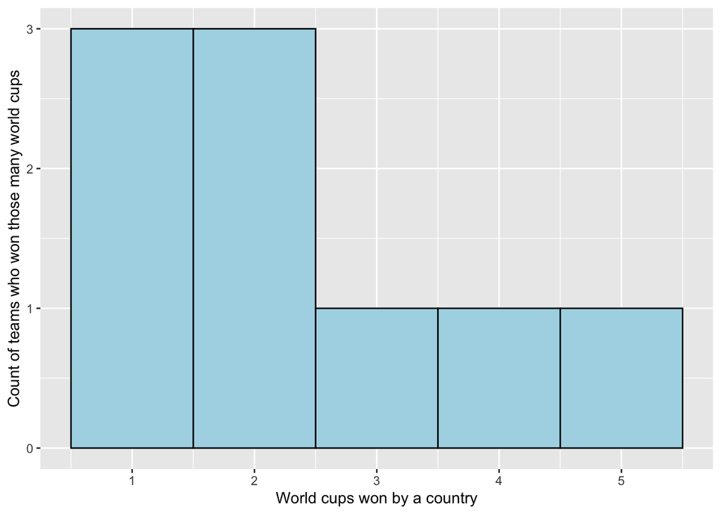

```r
# YOUR CODE HERE
count_data <- worldcups %>%
  group_by(worldcups$winner) %>%
  summarise(Count = n())

ggplot(count_data, aes(x = Count)) +
  geom_histogram(binwidth = 1, fill = "lightblue", color = "black") +
  labs(
    x = "World cups won by a country",
    y = "Count of teams who won those many world cups"
  )
```

Only 1 country each has won the world cup 3,4 and 5 times. 3 countries have won the world cup once and twice.

9. Create and interpret a multivariate visualization for a variable of your choice.

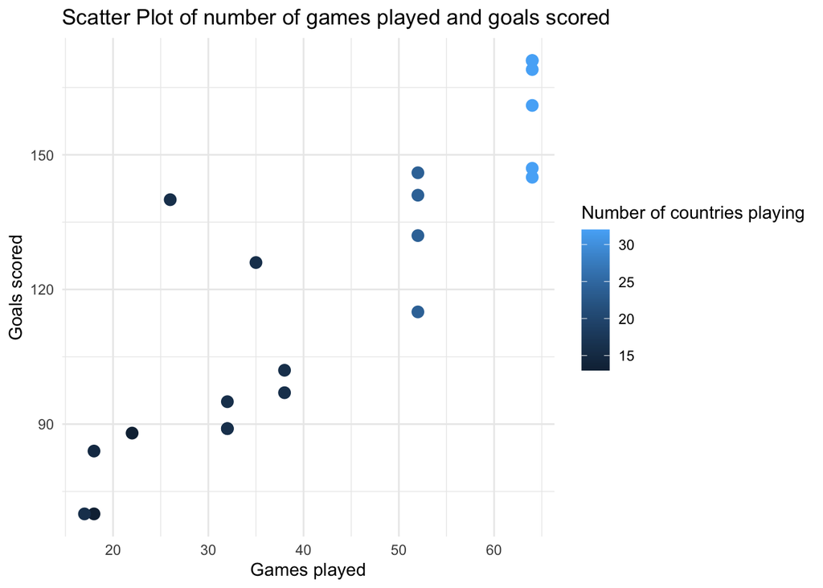

```r
# YOUR CODE HERE
ggplot(data = worldcups, aes(x = worldcups$games, y = worldcups$goals_scored)) +
  geom_point(aes(color = worldcups$teams), size = 3) +
  labs(
    title = "Scatter Plot of number of games played and goals scored",
    x = "Games played",
    y = "Goals scored",
    color = "Number of countries playing"
  ) +
  theme_minimal()
```

With more teams playing in the world cup, the number of games played increased and so did the number of goals.